# 431 Class 01

## Scatterplot of Prior Results, 1

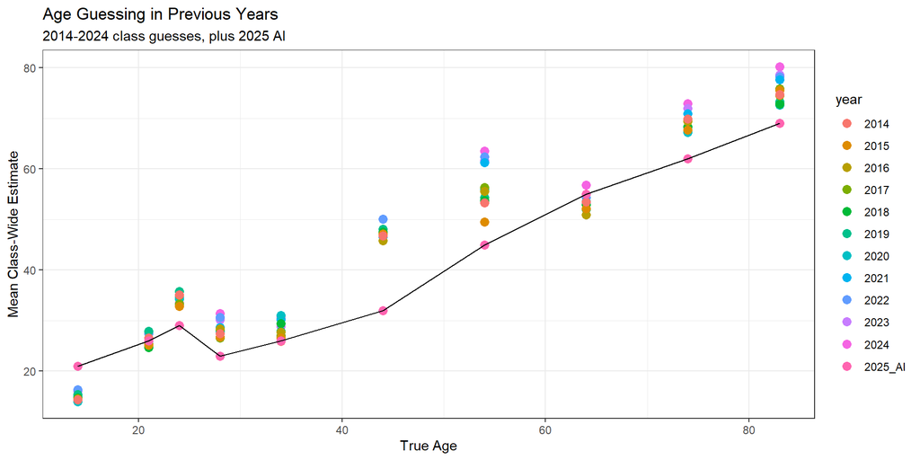

## Revised Scatterplot of Prior Results

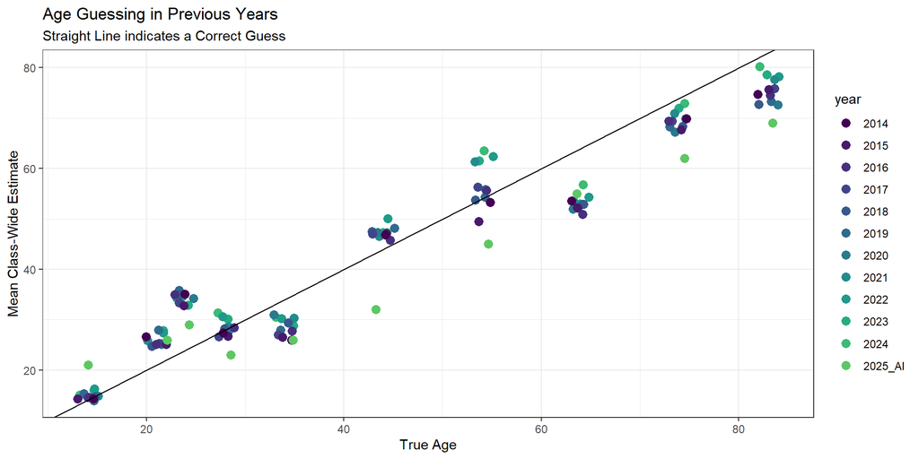

## Mean Class-Wide Guesses (2014-24)

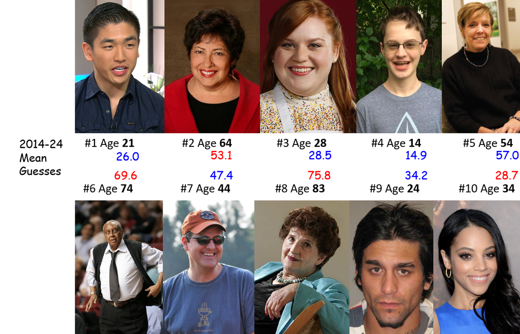

## Distribution of Guesses by Subject

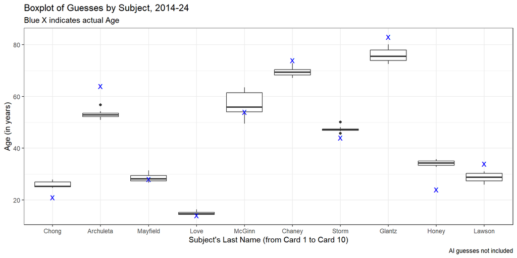

## Mean Class-Wide Errors (2014-24)

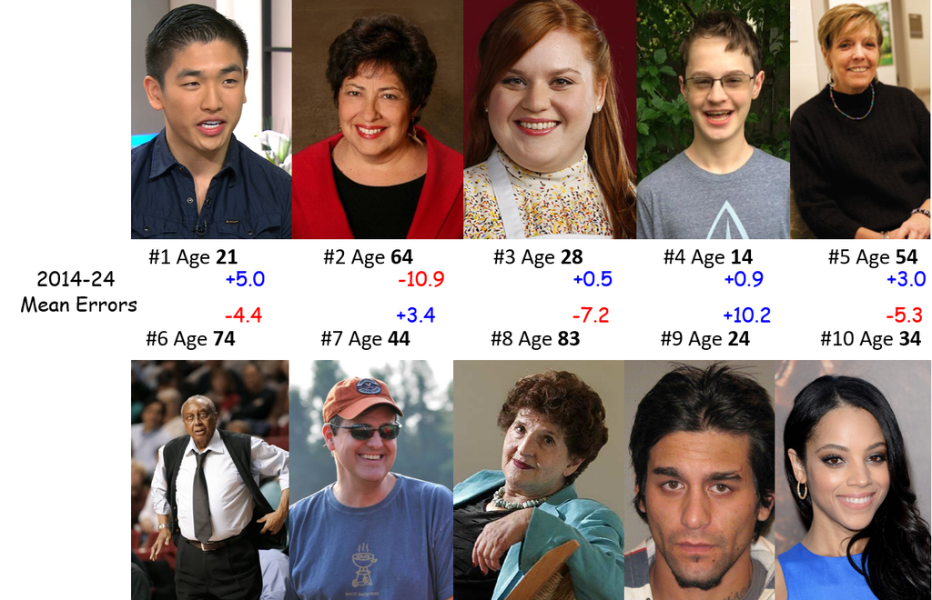

## 2024 Results: Labeled Scatterplot

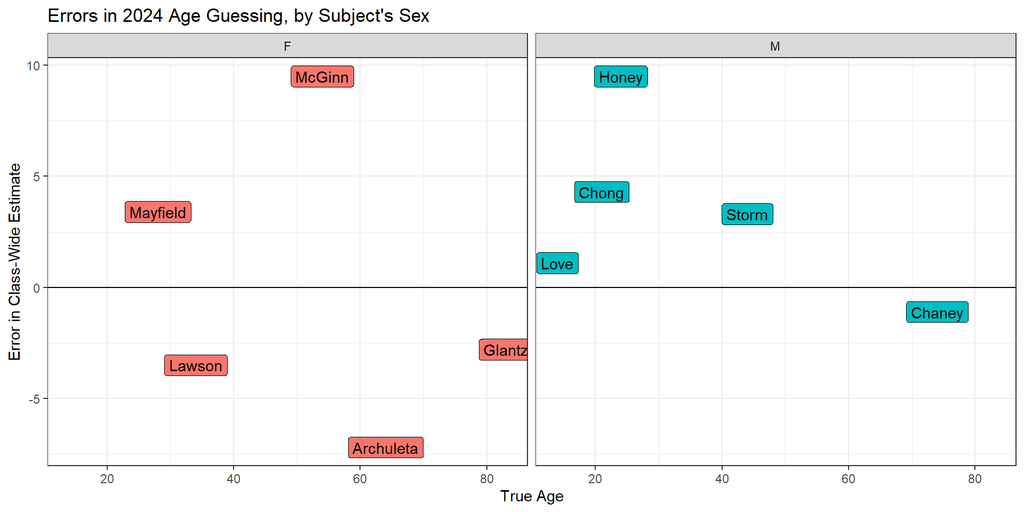

## Thanks for coming!

See you Thursday at 1 PM right here.

1. Complete the [Welcome to 431 survey](https://bit.ly/431-2025-welcome) (due **tomorrow** at noon.)
2. Review the [main course website](https://thomaselove.github.io/431-2025/), being sure to visit the [Course Calendar](https://thomaselove.github.io/431-2025/calendar.html).
3. Read through the [Course Syllabus](https://thomaselove.github.io/431-syllabus-2025/).
4. Obtain David Spiegelhalter’s *The Art of Statistics: How to Learn from Data* (~$20) and read the Introduction and Chapter 1.
5. [Install the R and RStudio software](https://thomaselove.github.io/431-2025/software.html) you’ll need on a computer you control.
6. Look at Dr. Love’s [Course Book](https://thomaselove.github.io/431-book/), especially Chapters 1-3.
7. Take a look at [Lab 01](https://github.com/THOMASELOVE/431-labs-2025/tree/main/lab1) (due 2025-09-17 at noon) which is your first substantial deliverable, and also glance at the instructions for [Project A](https://thomaselove.github.io/431-projectA-2025/).